# HBoxContainer

# HBoxContainer and VBoxContainer create rows and columns for your UI

`HBoxContainer` organizes `Control` children into a row. `VBoxContainer` organizes `Control` children into a column.

The main difference between an `HBoxContainer` and `VBoxContainer` is the direction they order their `Control` children: horizontally or vertically.

These two containers allow you to create complex UI layouts and automate `Control` node placement and sizing.

In this guide, you will learn:

- How to use the `VBoxContainer` and `HBoxContainer` nodes.
- How to use size flags.
- How to make a JRPG action list.
- How to make a level editor.

Contents:

- BoxContainer’s key features
  - Separation
  - Size Flags
- How to use a BoxContainer in practice
  - Fitting the UI to your screen
  - List of JRPG attack commands
  - Organising the main menu
  - Level editor
  - Grouping radio buttons
  - Login form
  - Settings screen
- Your questions
  - How do I create a grid of control nodes?
- Troubleshooting
  - Why are my Control children tiny?
  - Why did some of my buttons stop working?

## BoxContainer’s key features

### Separation

You can control how much space there is between child `Control` nodes.

By default, the *Separation* property is unchecked, and all children have `4` pixels of space between them.

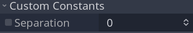

Below, you can see a small gap between buttons placed in a `VBoxContainer`.

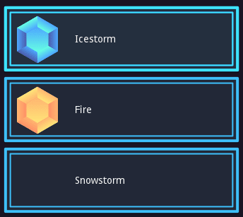

You can adjust this space in pixels by setting *Custom Constants -> Separation* in `HBoxContainer` or `VBoxContainer`.

You can set *Separation* to be `0` if you want your `Control` nodes to be flush against each other.

### Size Flags

All control nodes use *Size Flags* to position and size themselves relative to their parent.

Using this property effectively in a container like `HBoxContainer` or `VBoxContainer` is an essential step in getting your desired appearance.

There are four size flags for every `Control` node:

- *Fill*
- *Expand*
- *Shrink Center*
- *Shrink End*

There’s both a horizontal and vertical set of size flags for width and height.

*Fill* makes the child node fill the available space of its parent and either it becomes larger or its bounding box stretches to take available space.

*Expand* makes the child push other UI nodes to take up as much space as possible from their parent, even if it squashes other nodes. How much the `Control` expands adjusts based on other siblings trying to use *Expand*.

Here’s an example with a `ProgressBar` inside an `HBoxContainer`. First, the bar has no *Size Flags* set.

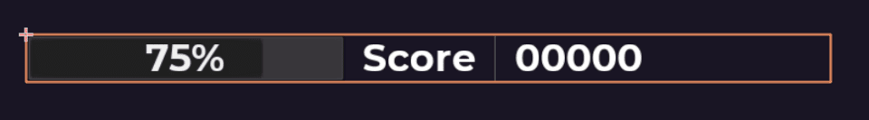

When turning on the horizontal *Expand* flag, it pushes the score to the right, increasing the size of its bounding box.

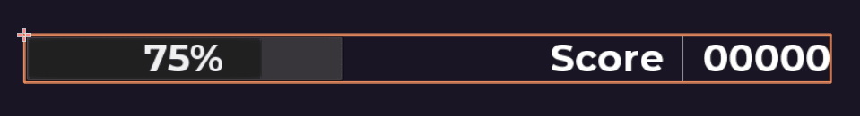

Turning on the *Fill* flag on top of that makes the bar fill up all the space available to it.

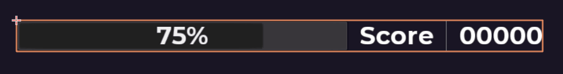

**Note:** Each `Control` child will take up equal amounts of space if they all have the *Expand* flag set, unless their minimum size is too big.

The *Shrink* flags only work for children with the *Fill* flag unchecked.

*Shrink Center* makes a child move to the center of its bounding box.

*Shrink End* moves a child to the right or bottom of its bounding box.

Unchecking *Shrink Center* and *Shrink End* moves a child to the top or left of its bounding box.

## How to use a BoxContainer in practice

### Fitting the UI to your screen

Because box containers split their existing space into columns or rows, they’re great at creating a structure for a more elaborate UI.

Containers are also essential for fitting your UI to different-sized screens.

Godot is both a powerful and highly customizable engine for designing interfaces.

There are near-endless UI configurations in Godot, but in this example, we focus on fitting your interface to the screen horizontally with a single `HBoxContainer`.

For this example, we’ll use `Label`, `ProgressBar`, and `VSeparator` nodes as children.

A `MarginContainer` is perfect for giving our interface a bit of breathing room at the edge of the screen. This gives us a slight margin between our UI in the `HBoxContainer` and the edge of the screen.

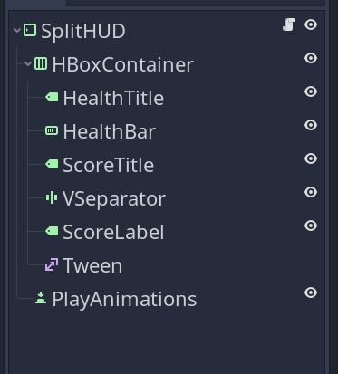

After tweaking the `Label` text and setting a few size flags, we can get a result that shows our player’s health and score in our game that fits perfectly to our screen size:

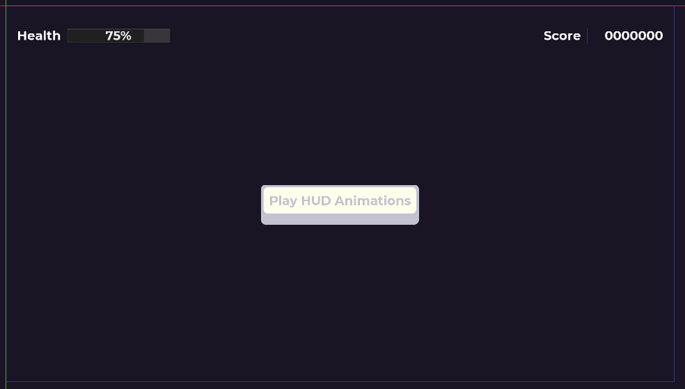

Notice how our health bar has a lot of distance between itself and the score label. The health bar has *Size Flags -> Horizontal -> Expand* set, with no other flags. This makes the health bar take up extra space, but it keeps the node at the left side of the container.

We could have moved this bar to the middle or the end of the gap by using the *Shrink Center* and *Shrink End* size flags, but we have neither of those checked, so the bar stays on the left side.

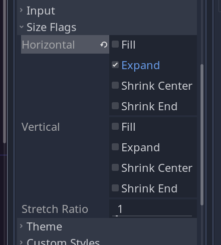

The rest of these nodes are using *Size Flags -> Horizontal -> Fill*.

You can read the PanelContainer guide to learn more about setting up `MarginContainer` as a root for UI scenes.

One last thing about this setup, we’re using a score counter with leading zeroes. We can turn a local `_score` variable, an integer, into a `String` with leading zeroes using a setter function:

```
var _score: int = 0 setget set_score

onready var _score_label: Label = $HBoxContainer/ScoreLabel
```

Whenever we try to change the `_score` by using `self._score`, the `set_score()` function gets called instead. We use GDScript format strings to have our seven leading zeroes. You can read more about [GDScript format strings in the official docs.](https://docs.godotengine.org/en/stable/getting_started/scripting/gdscript/gdscript_format_string.html)

This setter function also updates our integer variable as intended, so we can refer back to this variable elsewhere in our game:

```
func set_score(score_in: int) -> void:
    _score = score_in
    _score_label.text = "%07d" % _score
```

### List of JRPG attack commands

In JRPGs like *Final Fantasy VII*, the player can attack with buttons after waiting for their turn with a real-time clock.

[figure not shown]

We can use a `VBoxContainer` to hold our attack commands, as well as a `ProgressBar` showing us when our next attack can happen.

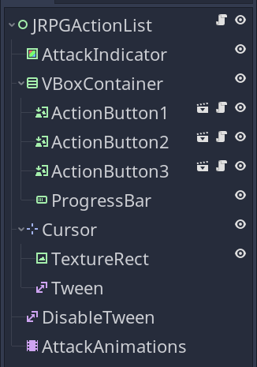

This gives us a vertical list of buttons with a bar at the bottom.

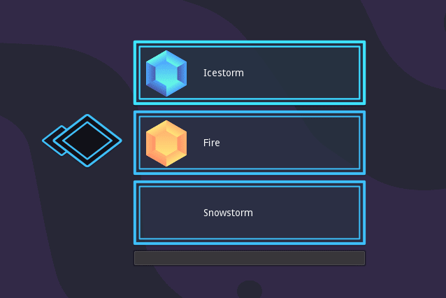

The cursor highlights which attack we’ll be using, and the `ColorRect` and `AnimationPlayer` are both here to play an animation representing our character’s attack.

Inside our `VBoxContainer` are custom `TextureButton` scenes containing a `Label`, a `TextureRect`, and some export variables to customize the two.

The *ActionButton* nodes use an `HBoxContainer` to align their children together:

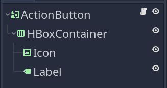

We override the `_pressed()` virtual function in the *ActionButton* script to not focus the button when pressing it. This prevents the player from navigating to other buttons inadvertently after making their choice.

Releasing focus only prevents navigating buttons with direction keys, which you can do by default in Godot, even when disabling UI elements.

```
## Individual button representing one combat action.
extends TextureButton

# Image to appear on the button.
export (Texture) var icon: Texture
# Text to appear on the button.
export (String) var text := ""

onready var _icon_node: TextureRect = $HBoxContainer/Icon
onready var _label_node: Label = $HBoxContainer/Label


func _ready() -> void:
    _icon_node.texture = icon
    _label_node.text = text


## Prevents the player from navigating to other buttons with the keyboard after pressing this one.
func _pressed() -> void:
    release_focus()
```

In our root script, we have a handful of nodes we need to define:

```
extends Control

onready var _button_container: VBoxContainer = $VBoxContainer
# This button takes the player's focus when all Buttons become enabled again.
onready var _first_button: TextureButton = $VBoxContainer/ActionButton1

# This Timer determines long to disable the buttons for after making an attack.
onready var _disable_tween: Tween = $DisableTween
onready var _progress_bar: ProgressBar = $VBoxContainer/ProgressBar

# Visual-only cursor to show the player's current choice.
onready var _cursor: Position2D = $Cursor
onready var _cursor_tween: Tween = $Cursor/Tween

onready var _attack_animations: AnimationPlayer = $AttackAnimations
```

Then, to use the *ActionButton* nodes inside the `VBoxContainer`, we need to connect to all of the buttons’ signals.

We can loop over the children of the `VBoxContainer` and connect to any `TextureButton` signals.

We’ll use the `mouse_entered` and `focus_entered` signals to move the cursor and use the `pressed` signal to cause animations to play.

```
func _ready() -> void:
    # This timeout signal re-enables all buttons after the player makes a choice.
    _disable_tween.connect("tween_all_completed", self, "_set_buttons_disabled", [false])

    for child in _button_container.get_children():
        if child is TextureButton:
            child.connect("pressed", self, "_on_ActionButton_pressed", [child])
            child.connect("mouse_entered", self, "_move_cursor_to", [child.get_global_rect().position])
            child.connect("focus_entered", self, "_move_cursor_to", [child.get_global_rect().position])

    # Allow all buttons to be pressed at the start of the scene.
    _set_buttons_disabled(false)
```

This system disables the action buttons once the player attacks until the `ProgressBar` says we’re ready to attack again.

We can use the *Disabled* property of a `TextureButton`, and we can disable its *Focus Mode* so the cursor doesn’t continue to move once we’ve made a choice. We also use the cursor’s `Tween` to fade its alpha value out until we’re ready to attack again.

```
## Disables and prevent buttons from being focused, hides the cursor.
func _set_buttons_disabled(is_disabled: bool) -> void:
    for child in _button_container.get_children():
        # Ignore non-button children from this loop.
        if child is TextureButton:
            child.disabled = is_disabled
            child.focus_mode = Control.FOCUS_NONE if is_disabled else Control.FOCUS_ALL

    # Hide the cursor to help indicate if the buttons are enabled or not.
    _cursor_tween.interpolate_property(_cursor, "modulate:a", 1.0 if is_disabled else 0.0, 0.0 if is_disabled else 1.0, 0.25, Tween.TRANS_SINE, Tween.EASE_IN_OUT)
    _cursor_tween.start()

    # If we're enabling all buttons, grab the focus of the first button to let non-mouse users navigate the buttons.
    if not is_disabled:
        _first_button.grab_focus()
```

We can make a function to move our cursor to the *AttackButton* smoothly.

```
## Tweens the cursor's position to focused ActionButton.
func _move_cursor_to(position: Vector2) -> void:
    _cursor_tween.interpolate_property(_cursor, "position", _cursor.position, position, 0.5, Tween.TRANS_QUART, Tween.EASE_OUT)
    _cursor_tween.start()
```

Finally, we can use a `match` statement to check the attack’s name is valid and play the corresponding attack name in the `AnimationPlayer`. Then we can disable our buttons and start the progress bar with a `Tween`.

```
## Matches the Button text to play a corresponding animation.
func _on_ActionButton_pressed(pressed_button: TextureButton) -> void:
    _move_cursor_to(pressed_button.get_global_rect().position)
    match pressed_button.text:
        "Icestorm", "Fire", "Snowstorm":
            _attack_animations.play(pressed_button.text)
        var unexpected_case:
            push_error("Pressed button text \"%s\" was not found in _on_ActionButton_pressed." % [unexpected_case])
    # Disable all buttons. The timer's timeout signal will re-enable them.
    _set_buttons_disabled(true)
    _disable_tween.interpolate_property(_progress_bar, "value", 100, 0, 2.0)
    _disable_tween.start()
```

We used a `Tween` to control the waiting time between attacks, but a `Timer` is also a fine choice to expose the waiting period.

In addition to this guide, you can read about creating a turn-based attack in the Button guide.

### Organising the main menu

Box containers can let you organize all your main menu items with ease for a clean aesthetic.

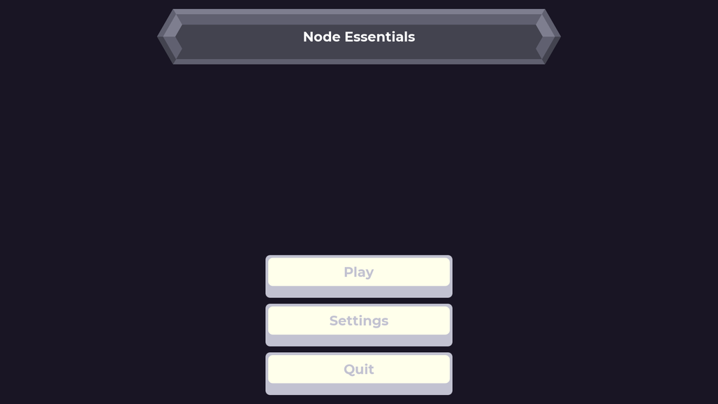

`VBoxContainer` and `HBoxContainer` nodes are perfect for holding similar buttons together, like a play, settings, or quit button.

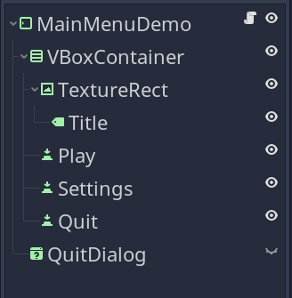

The process is as simple as adding the box container in the orientation you want, setting its size, and adding your buttons as children.

Another *Main Menu* example, featuring animations, can be found in Button guide.

You can use a `ConfirmationDialog` as a simple way to make sure the player wants to quit their game or offer options before starting a new game.

```
extends MarginContainer

onready var _quit_button: Button = $VBoxContainer/Quit
onready var _quit_dialog: ConfirmationDialog = $QuitDialog


func _ready() -> void:
    _quit_button.connect("pressed", _quit_dialog, "popup")
```

### Level editor

Level editors can have many tools and buttons, so it’s important to position them carefully on the screen.

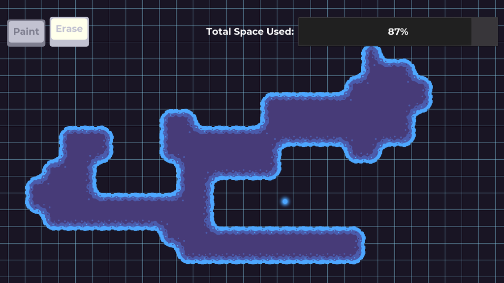

As seen on the toolbar above, using `VBoxContainer` or `HBoxContainer`, we can create toolbars filled with `Button` and `ProgressBar` nodes to give us more information about the level we’re editing.

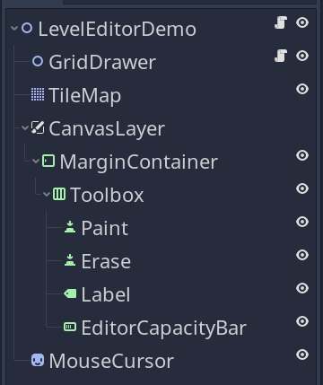

In our level editor, we added a capacity bar found in level editors on many console games to demonstrate how `HBoxContainer` can display other elements and handle added complexity to a level editor system like this one.

```
extends Node2D

onready var PaintCursorTexture := preload("res://common/VFX/LaserBeam2D/glowing_circle.png")
onready var EraseCursorTexture := preload("res://common/blackhole.png")

## -1 clears a cell. Tileset 0 is the only one assigned to the Tilemap.
const MODES := {"paint": 0, "erase": -1}

## Positions surrounding the clicked cell are painted in a 3x3 square around the cursor.
const SURROUNDING_CELLS := [
    Vector2(-1, 1),
    Vector2.DOWN,
    Vector2(1, 1),
    Vector2.LEFT,
    Vector2.ZERO,
    Vector2.RIGHT,
    Vector2(-1, -1),
    Vector2.UP,
    Vector2(1, -1),
]

# This integer determines which tile to use on a cell. We get it from the MODES
# constant, after reading Button text as a key.
var _current_mode := 0

onready var _tilemap: TileMap = $TileMap
# Holds the top bar of buttons and control nodes. We iterate through its children
# to find buttons to connect.
onready var _toolbox: HBoxContainer = $CanvasLayer/MarginContainer/Toolbox

# Limits how many tiles we can paint onto the grid before we have to erase some.
onready var _editor_capacity_bar: ProgressBar = $CanvasLayer/MarginContainer/Toolbox2/EditorCapacityBar
onready var _mouse_cursor: Sprite = $MouseCursor
```

To set up the top toolbar, we added a `MarginContainer` to get some spacing around the edge of the screen.

Then we can add an `HBoxContainer` which fills horizontally and contains two buttons.

After we unchecked the *Vertical -> Fill* size flag, it positions at the top of the `MarginContainer`.

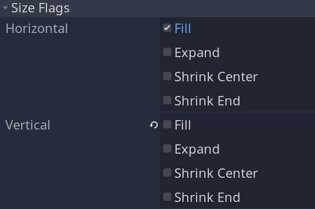

We also turn off the *Vertical -> Fill* size flag, so the toolbar doesn’t fill all the available vertical space.

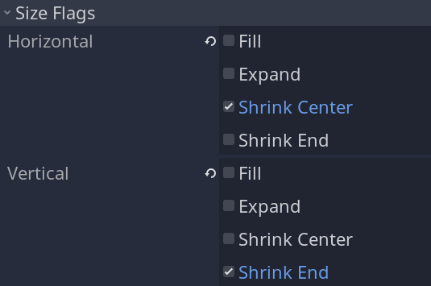

For the rest of our scene, we can use the toolbox `HBoxContainer` to connect the buttons in our toolbox to a function that reads their button text.

We loop over all of its children and connect their signals to a function.

The `update_painting_mode()` function matches the button text to one of the modes in the `MODES` constant from before:

```
func _ready() -> void:
    for node in _toolbox.get_children():
        if node is Button:
            node.connect("pressed", self, "update_painting_mode", [node.text])
```

The `update_painting_mode()` function changes the look of the cursor based on our selected mode, but it also uses `assert()` to ensure the mode we’re switching to is a valid choice.

Using `assert()` like this helps prevent us from making more buttons without using an associated key in the `MODES` dictionary.

```
## Updates the current mode and mouse cursor based on the pressed button.
func update_painting_mode(key: String) -> void:
    # Ensure we're assinging the _current_mode to something in the MODES dictionary.
    assert(key.to_lower() in MODES)
    _current_mode = MODES[key.to_lower()]
    _mouse_cursor.texture = PaintCursorTexture if _current_mode == MODES["paint"] else EraseCursorTexture
    _mouse_cursor.scale = Vector2(2.0, 2.0) if _current_mode == MODES["paint"] else Vector2(1.0, 1.0)
```

The core of this script is painting the tiles. The `paint_cells()` function prevents us from painting if our capacity bar is full and we cannot paint any more cells.

Next, we use the `SURROUNDING_CELLS` array to paint the tile that we clicked and its surrounding cells. Painting one tile at a time with this tileset can be tedious for the scale, so we opted to make the paintbrush larger this way.

If the cell’s last state is not the same as the new state we gave it, we can update our capacity bar.

```
## paints cells in a 3x3 cell grid based on an input position.
func paint_cells(cell_position: Vector2) -> void:
    var is_map_full := _editor_capacity_bar.get_as_ratio() == 1.0
    if is_map_full and _current_mode == MODES["paint"]:
        return

    var cell := _tilemap.world_to_map(cell_position)

    # Cycle through the 3x3 grid of cells to paint.
    for offset in SURROUNDING_CELLS:
        var offset_cell: Vector2 = cell + offset
        var previous_state := _tilemap.get_cellv(offset_cell)

        # Paint the cell using the value in the modes selection.
        _tilemap.set_cellv(offset_cell, _current_mode)

        # Apply the autotiling rules for the cell.
        _tilemap.update_bitmask_area(offset_cell)

        if previous_state != _current_mode:
            adjust_capacity_bar()
```

This capacity bar checks how many of our cells are occupied with `get_used_cells().size()`. If we had to extend this with more types of cells, and some cells took up more space than others, we could use `get_used_cells_by_id().size()` to factor more expensive cells into our capacity as well.

```
## Sets the bar's value based on number of occupied cells in the TileMap.
func adjust_capacity_bar() -> void:
    _editor_capacity_bar.value = _tilemap.get_used_cells().size()
```

Finally, we can hook all of this up to the player’s input. Clicking paints the cells, and moving the mouse with the click button down re-triggers the `paint_cells()` function.

```
func _unhandled_input(event: InputEvent) -> void:
    if Input.is_action_pressed("click"):
        paint_cells(get_global_mouse_position())

    if event is InputEventMouseMotion:
        _mouse_cursor.position = event.position
```

### Grouping radio buttons

The box container nodes are great for aligning like-buttons that a group ties together.

We have a demo that shows how to use `HBoxContainer` to create a custom radio button in the Button guide.

### Login form

A `VBoxContainer` is excellent at simulating the alignment of text fields and buttons found in most modern websites.

We have a demo that shows how to use `VBoxContainer` to create a login form in the LineEdit guide.

### Settings screen

A settings screen often has many switches, buttons, and sliders to give the user tweakable options. `VBoxContainer` and `HBoxContainer` are great at structuring these elements together.

We have a demo that shows how to use `HBoxContainer` and `VBoxContainer` to create a settings menu in the Viewport guide.

## Your questions

### How do I create a grid of control nodes?

A grid is handy for UI with a more complex structure, like an inventory screen. `GridContainer` is a node designed for this purpose. You can add nodes to a `GridContainer`, and it organizes the nodes for you.

If you need empty slots, fill the `GridContainer` with `PanelContainer` nodes and add children to the `PanelContainer` nodes. You can read the PanelContainer guide to learn more.

You can still create a grid using a `VBoxContainer` with several `HBoxContainer` nodes inside, but increasing the grid size means adding more `HBoxContainer` children. `GridContainer` does the same thing in a single node, just by adjusting its *Columns* property.

## Troubleshooting

### Why are my Control children tiny?

The size and position of a `Control` child are usually handled for you by the box container, using the *Size Flags* and *Min Size* properties of its children. However, this sometimes means that children shrink as small as possible since the containers optimize the space inside them.

A child with a size of `Vector2(1, 1)` usually happens when:

- You didn’t check the *Fill* size flag on the child.
- You didn’t set a *Min Size* on the child.

Enable the *Fill* flag, so the child can take up as much space as it’s allowed inside the container.

Enable the *Expand* flag to give the child more space around its siblings.

Set the *Min Size* property to ensure the child is at least a certain size. This is useful when showing a `TextureRect` inside a `Container` with other sibling nodes.

### Why did some of my buttons stop working?

By default, an `HBoxContainer` and a `VBoxContainer` detect mouse input events and pass them to their children. You can change this behavior by changing the *Mouse -> Filter*.

The entire space of the container is a target for the mouse. Even if there’s nothing in an `HBoxContainer` or `VBoxContainer`, the mouse normally can’t reach any nodes behind the containers.

In the following image, you can see that the `HBoxContainer` completely covers the button behind it.

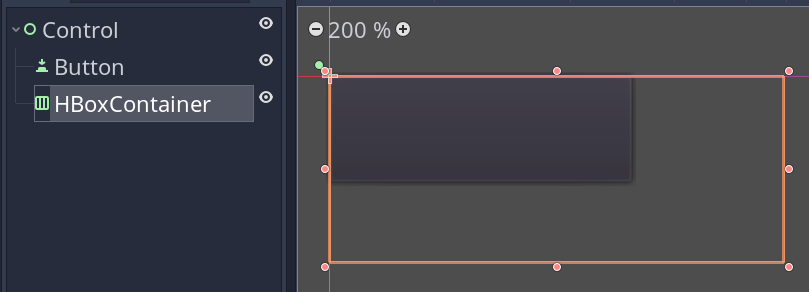

You can fix this by changing the box container’s *Mouse -> Filter* property to *Ignore*.